# NYCFlights: Arrival Delay Logictic Model

Dennis Raj

April 26, 2017

```r
# from the assignment -- predict delays >= 22 minutes

# Filter the data to remove na's and limit the data to arrival delays greater than or equal to 22 minutes
flights$cat_delay <- "ontime"
flights$cat_delay[flights$arr_delay >= 22] <- "late"
flights$cat_delay <- factor(flights$cat_delay)

#Double check the counts of each of the types of flights
flights %>% select(cat_delay, arr_delay) %>% group_by(cat_delay) %>%
                            summarize(count = n())
```

```
## # A tibble: 2 × 2
##   cat_delay  count
##      <fctr>  <int>
## 1      late  64959
## 2    ontime 271817
```

```r
#limit the data to variables of interest

flights_clean <- flights %>% select(cat_delay, month.x, dep_delay, carrier, origin, dest, distance)
```

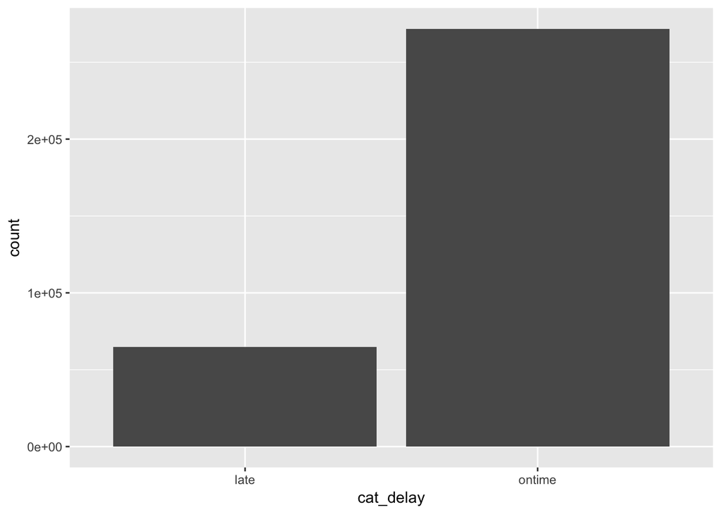

```r
ggplot(data = flights_clean, aes(cat_delay)) + geom_histogram(stat="count")
```

```r
split <- sample.split(flights_clean$cat_delay, SplitRatio = 0.75)
flights_train <- subset(flights_clean, split==TRUE)
flights_test <- subset(flights_clean, split == FALSE)

#logistic regression model - first test

fit_start <- glm(formula = cat_delay ~ month.x + dep_delay + carrier + origin + dest + distance, data = flights_train , family = binomial(link = "logit"))
#summary of the fit
summary(fit_start)
```

```
##
## Call:
## glm(formula = cat_delay ~ month.x + dep_delay + carrier + origin +
##     dest + distance, family = binomial(link = "logit"), data = flights_train)
##
## Deviance Residuals:
##     Min       1Q   Median       3Q      Max
## -3.6418   0.2067   0.2717   0.3419   8.4904
##
## Coefficients:
##               Estimate Std. Error  z value Pr(>|z|)
## (Intercept)   5.068454   3.728565    1.359 0.174033
## month.x      -0.004174   0.002341   -1.783 0.074524 .
## dep_delay    -0.099737   0.000482 -206.936  < 2e-16 ***
## carrierAA    -0.181605   0.058591   -3.100 0.001938 **
## carrierAS     0.231294   0.241559    0.958 0.338313
## carrierB6    -0.529169   0.050231  -10.535  < 2e-16 ***
## carrierDL    -0.063860   0.052118   -1.225 0.220468
## carrierEV    -0.377634   0.052411   -7.205 5.80e-13 ***
## carrierF9    -0.761307   0.154380   -4.931 8.17e-07 ***
## carrierFL    -0.538644   0.098347   -5.477 4.33e-08 ***
## carrierHA    -0.730506   0.421784   -1.732 0.083284 .
## carrierMQ    -0.761552   0.052601  -14.478  < 2e-16 ***
## carrierOO    -0.858273   0.924662   -0.928 0.353303
## carrierUA    -0.015925   0.057009   -0.279 0.779982
## carrierUS    -0.599215   0.064519   -9.287  < 2e-16 ***
## carrierVX     0.133847   0.089422    1.497 0.134444
## carrierWN     0.282921   0.076793    3.684 0.000229 ***
## carrierYV    -0.390662   0.206509   -1.892 0.058525 .
## originJFK     0.045092   0.039017    1.156 0.247808
## originLGA    -0.067186   0.038401   -1.750 0.080189 .
## destACK      -1.547133   3.353406   -0.461 0.644539
## destALB      -0.898475   3.438777   -0.261 0.793879
## destANC      10.482349  87.533810    0.120 0.904680
## destATL      -1.342985   2.199193   -0.611 0.541417
## destAUS      -0.495345   0.681110   -0.727 0.467066
## destAVL      -1.663772   2.544387   -0.654 0.513177
## destBDL      -0.954645   3.495657   -0.273 0.784781
## destBGR      -0.725319   2.989014   -0.243 0.808268
## destBHM       0.088047   2.005397    0.044 0.964980
```

[output cut: 91 more lines]

```
## destTVC      -0.801685   2.459508   -0.326 0.744460
## destTYS      -1.319850   2.442643   -0.540 0.588965
## destXNA      -0.979492   1.423035   -0.688 0.491256
## distance     -0.001090   0.002048   -0.532 0.594792
## ---
## Signif. codes:  0 '***' 0.001 '**' 0.01 '*' 0.05 '.' 0.1 ' ' 1
##
## (Dispersion parameter for binomial family taken to be 1)
##
##     Null deviance: 245045  on 246422  degrees of freedom
## Residual deviance: 113222  on 246299  degrees of freedom
##   (6159 observations deleted due to missingness)
## AIC: 113470
##
## Number of Fisher Scoring iterations: 10
```

```r
#testing the anova of the fit using Chi-squared
anova(fit_start, test = 'Chisq')
```

```
## Analysis of Deviance Table
##
## Model: binomial, link: logit
##
## Response: cat_delay
##
## Terms added sequentially (first to last)
##
##
##            Df Deviance Resid. Df Resid. Dev  Pr(>Chi)
## NULL                      246422     245045
## month.x     1       51    246421     244994 9.159e-13 ***
## dep_delay   1   130247    246420     114747 < 2.2e-16 ***
## carrier    15      944    246405     113803 < 2.2e-16 ***
## origin      2       32    246403     113771 9.500e-08 ***
## dest      103      548    246300     113222 < 2.2e-16 ***
## distance    1        0    246299     113222    0.5742
## ---
## Signif. codes:  0 '***' 0.001 '**' 0.01 '*' 0.05 '.' 0.1 ' ' 1
```

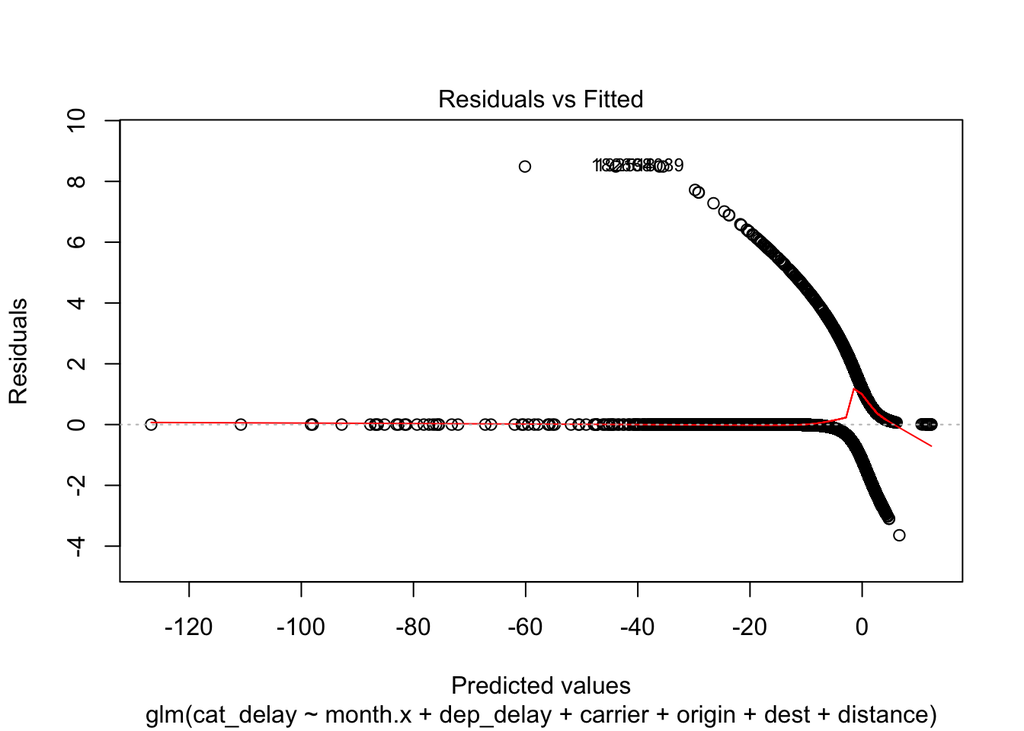

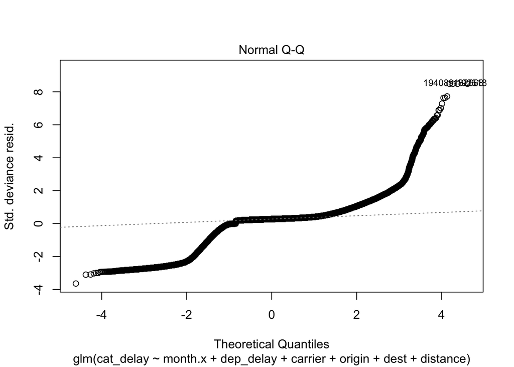

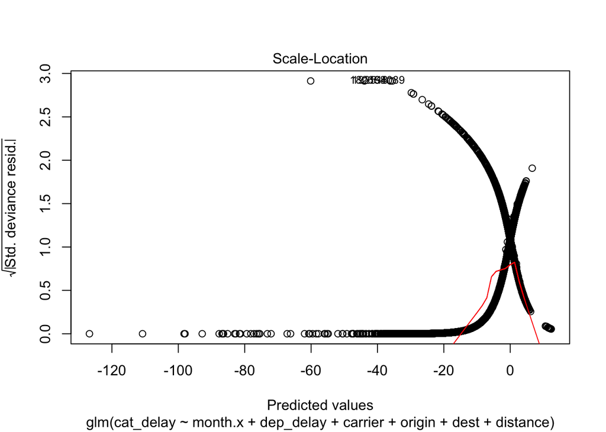

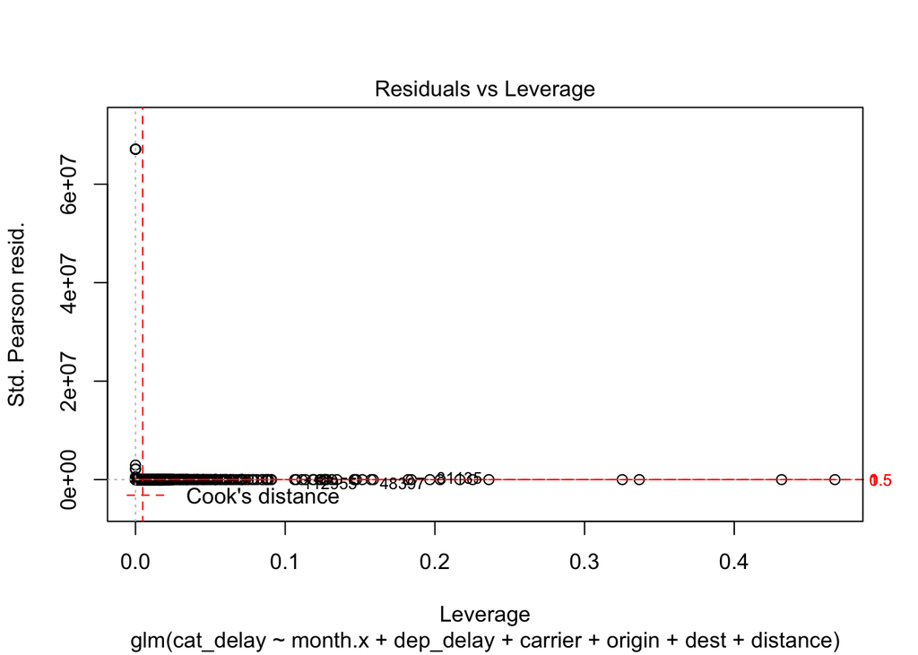

```r
#plotting the fit
plot(fit_start)
```

```r
#testing the fit with the new data
fit_test <- glm(formula = cat_delay ~ month.x + dep_delay + carrier + origin + dest + distance, data = flights_test , family = binomial(link = "logit"))
#summary of the fit
summary(fit_test)
```

```
##
## Call:
## glm(formula = cat_delay ~ month.x + dep_delay + carrier + origin +
##     dest + distance, family = binomial(link = "logit"), data = flights_test)
##
## Deviance Residuals:
##     Min       1Q   Median       3Q      Max
## -3.2007   0.2027   0.2695   0.3404   8.4904
##
## Coefficients:
##               Estimate Std. Error  z value Pr(>|z|)
## (Intercept)  5.507e+00  6.407e+00    0.860  0.39003
## month.x      1.094e-04  4.085e-03    0.027  0.97864
## dep_delay   -1.000e-01  8.340e-04 -119.948  < 2e-16 ***
## carrierAA   -2.728e-01  1.022e-01   -2.671  0.00757 **
## carrierAS    3.251e-01  4.469e-01    0.728  0.46689
## carrierB6   -5.144e-01  8.788e-02   -5.854 4.81e-09 ***
## carrierDL   -1.017e-01  9.082e-02   -1.120  0.26259
## carrierEV   -4.261e-01  9.153e-02   -4.655 3.23e-06 ***
## carrierF9   -8.371e-01  2.863e-01   -2.924  0.00346 **
## carrierFL   -5.465e-01  1.703e-01   -3.210  0.00133 **
## carrierHA    3.904e-01  6.408e-01    0.609  0.54233
## carrierMQ   -8.832e-01  9.106e-02   -9.699  < 2e-16 ***
## carrierOO   -1.485e+00  1.375e+00   -1.079  0.28037
## carrierUA   -3.554e-02  9.987e-02   -0.356  0.72196
## carrierUS   -4.742e-01  1.104e-01   -4.296 1.74e-05 ***
## carrierVX    2.836e-01  1.606e-01    1.765  0.07750 .
## carrierWN    3.168e-01  1.339e-01    2.366  0.01796 *
## carrierYV   -4.853e-01  3.490e-01   -1.390  0.16438
## originJFK    7.467e-03  6.694e-02    0.112  0.91118
## originLGA   -8.314e-02  6.626e-02   -1.255  0.20958
## destACK     -6.844e-01  5.795e+00   -0.118  0.90599
## destALB     -1.768e+00  5.907e+00   -0.299  0.76474
## destANC      3.602e+00  6.338e+00    0.568  0.56980
## destATL     -1.537e+00  3.781e+00   -0.406  0.68441
## destAUS     -4.787e-01  1.177e+00   -0.407  0.68418
## destAVL     -1.340e+00  4.392e+00   -0.305  0.76036
## destBDL     -1.374e+00  6.001e+00   -0.229  0.81886
## destBGR     -8.003e-01  5.144e+00   -0.156  0.87638
## destBHM     -6.402e-01  3.452e+00   -0.185  0.85287
```

[output cut: 90 more lines]

```
## destTVC     -1.403e+00  4.251e+00   -0.330  0.74140
## destTYS     -1.571e+00  4.197e+00   -0.374  0.70816
## destXNA     -1.290e+00  2.449e+00   -0.527  0.59838
## distance    -1.326e-03  3.520e-03   -0.377  0.70636
## ---
## Signif. codes:  0 '***' 0.001 '**' 0.01 '*' 0.05 '.' 0.1 ' ' 1
##
## (Dispersion parameter for binomial family taken to be 1)
##
##     Null deviance: 81664  on 82097  degrees of freedom
## Residual deviance: 37477  on 81975  degrees of freedom
##   (2096 observations deleted due to missingness)
## AIC: 37723
##
## Number of Fisher Scoring iterations: 11
```

```r
#testing the anova of the new fit
anova(fit_test, test = 'Chisq')
```

```
## Analysis of Deviance Table
##
## Model: binomial, link: logit
##
## Response: cat_delay
##
## Terms added sequentially (first to last)
##
##
##            Df Deviance Resid. Df Resid. Dev  Pr(>Chi)
## NULL                       82097      81664
## month.x     1       32     82096      81631 1.250e-08 ***
## dep_delay   1    43576     82095      38055 < 2.2e-16 ***
## carrier    15      329     82080      37726 < 2.2e-16 ***
## origin      2        6     82078      37720    0.0418 *
## dest      102      242     81976      37478 1.877e-13 ***
## distance    1        0     81975      37477    0.6670
## ---
## Signif. codes:  0 '***' 0.001 '**' 0.01 '*' 0.05 '.' 0.1 ' ' 1
```

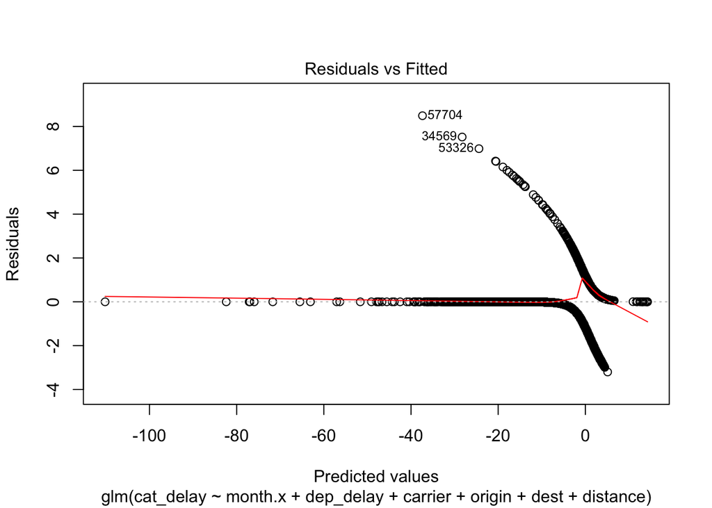

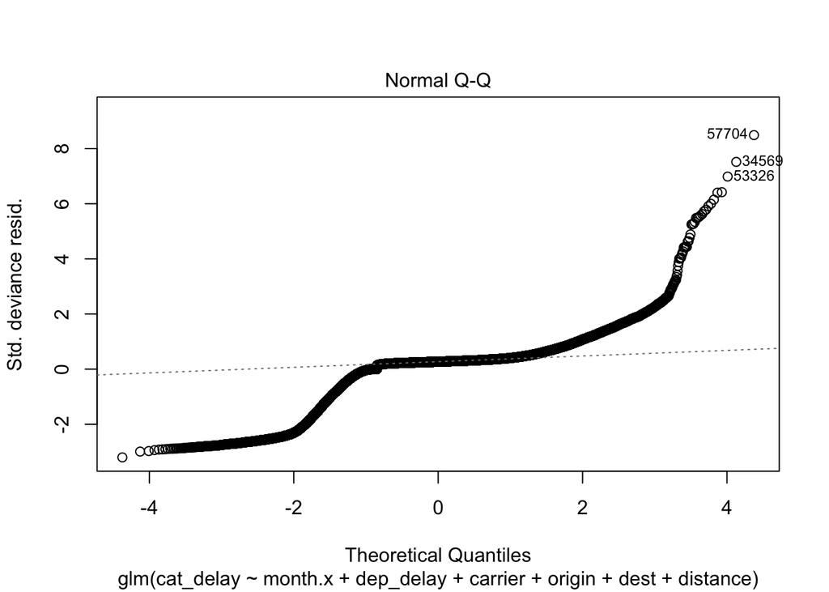

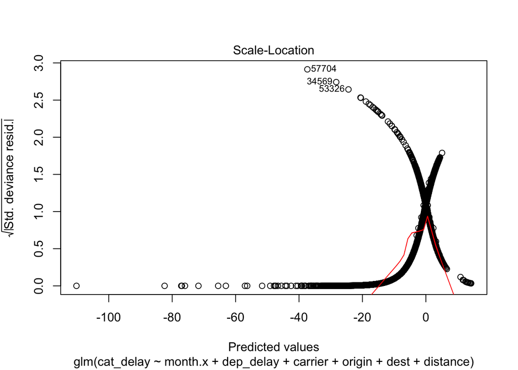

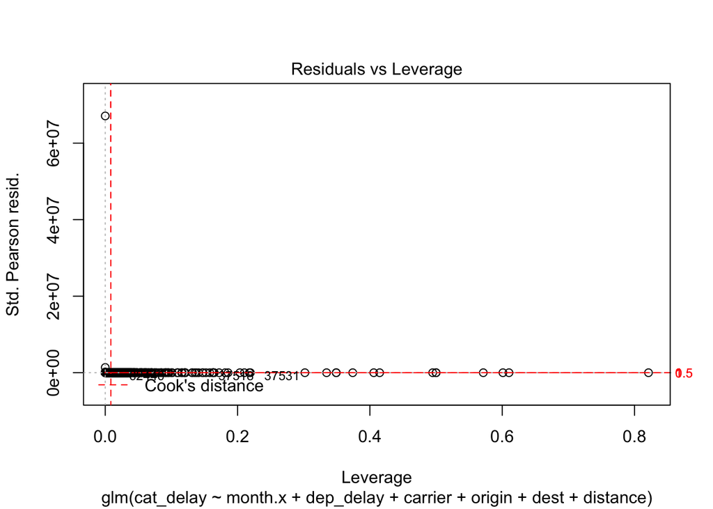

```r
#plotting the new fit
plot(fit_test)
```

**Hint:** For plotting curves see `?graphics::curve` or `?ggplot2::stat_function`

# NYCFlights Model

Using the rectangular data that you created from the earlier assignment and following theexample from the text and class, create a model for arr_delay >= 22 minutes. Describe/Explain each of the steps and show all work.

KNIT YOUR DOCUMENT AS *HTML* AND SUBMIT IT AND THE `Rmd` file to your repository.

# Question:

Is this a good model? (Write your answer here.) Probably not, since I wasn’t able to complete this assignment.

# PART B:

Your model should be good at explaining tardiness. Now, assume that your job is to predict arrival delays a month in advance. You can no longer use all the features in your model. Retrain your model using only features that will be *known* only a month in advance of the departure time. Show all steps as above.

```r
flights_update <- flights %>% select(cat_delay, month.x, carrier, origin, dest)

fit_update <- glm(formula = cat_delay ~ month.x + carrier + origin + dest, data = flights_clean, family = binomial(link = "logit"))

summary(fit_update)
```

```
##
## Call:
## glm(formula = cat_delay ~ month.x + carrier + origin + dest,
##     family = binomial(link = "logit"), data = flights_clean)
##
## Deviance Residuals:
##     Min       1Q   Median       3Q      Max
## -2.2447   0.5374   0.6075   0.6875   1.2541
##
## Coefficients:
##               Estimate Std. Error z value Pr(>|z|)
## (Intercept)   1.060165   0.146732   7.225 5.00e-13 ***
## month.x       0.009776   0.001296   7.546 4.48e-14 ***
## carrierAA     0.339916   0.030640  11.094  < 2e-16 ***
## carrierAS     0.752312   0.130833   5.750 8.92e-09 ***
## carrierB6    -0.107129   0.025453  -4.209 2.57e-05 ***
## carrierDL     0.393229   0.026995  14.567  < 2e-16 ***
## carrierEV    -0.317302   0.025850 -12.275  < 2e-16 ***
## carrierF9    -0.378811   0.091936  -4.120 3.78e-05 ***
## carrierFL    -0.277991   0.056227  -4.944 7.65e-07 ***
## carrierHA     0.915380   0.243318   3.762 0.000169 ***
## carrierMQ    -0.098043   0.026971  -3.635 0.000278 ***
## carrierOO    -0.178442   0.429230  -0.416 0.677611
## carrierUA     0.233357   0.029413   7.934 2.12e-15 ***
## carrierUS     0.470917   0.034007  13.848  < 2e-16 ***
## carrierVX     0.375896   0.049000   7.671 1.70e-14 ***
## carrierWN     0.116531   0.040549   2.874 0.004055 **
## carrierYV    -0.337780   0.100003  -3.378 0.000731 ***
## originJFK     0.012362   0.016422   0.753 0.451581
## originLGA     0.073282   0.014244   5.145 2.68e-07 ***
## destACK       0.688250   0.223426   3.080 0.002067 **
## destALB       0.249715   0.181097   1.379 0.167924
## destANC       0.579074   1.078740   0.537 0.591402
## destATL       0.083059   0.145775   0.570 0.568828
## destAUS       0.061046   0.151964   0.402 0.687896
## destAVL       0.573734   0.209726   2.736 0.006226 **
## destBDL       0.549873   0.186499   2.948 0.003194 **
## destBGR       0.280249   0.189606   1.478 0.139391
## destBHM       0.087307   0.194833   0.448 0.654073
## destBNA       0.199720   0.147584   1.353 0.175973
```

[output cut: 89 more lines]

```
## destTPA       0.129826   0.146380   0.887 0.375125
## destTUL      -0.427458   0.184665  -2.315 0.020625 *
## destTVC       0.173831   0.272446   0.638 0.523450
## destTYS      -0.200665   0.168575  -1.190 0.233905
## destXNA       0.415299   0.164822   2.520 0.011746 *
## ---
## Signif. codes:  0 '***' 0.001 '**' 0.01 '*' 0.05 '.' 0.1 ' ' 1
##
## (Dispersion parameter for binomial family taken to be 1)
##
##     Null deviance: 330296  on 336775  degrees of freedom
## Residual deviance: 325677  on 336653  degrees of freedom
## AIC: 325923
##
## Number of Fisher Scoring iterations: 9
```

```r
anova(fit_update, test = 'Chisq')
```

```
## Analysis of Deviance Table
##
## Model: binomial, link: logit
##
## Response: cat_delay
##
## Terms added sequentially (first to last)
##
##
##          Df Deviance Resid. Df Resid. Dev  Pr(>Chi)
## NULL                    336775     330296
## month.x   1     59.3    336774     330237 1.352e-14 ***
## carrier  15   3578.4    336759     326658 < 2.2e-16 ***
## origin    2     29.5    336757     326629 3.834e-07 ***
## dest    104    951.8    336653     325677 < 2.2e-16 ***
## ---
## Signif. codes:  0 '***' 0.001 '**' 0.01 '*' 0.05 '.' 0.1 ' ' 1
```

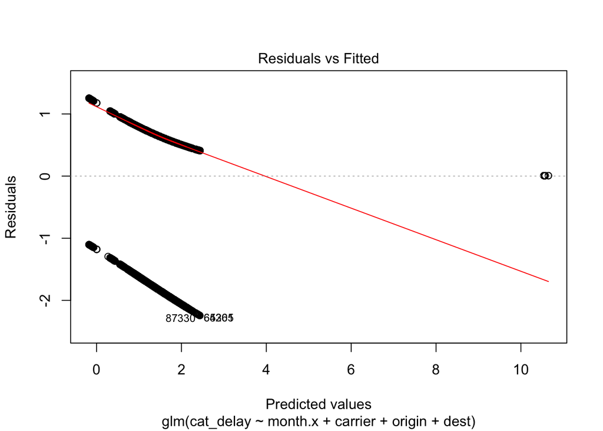

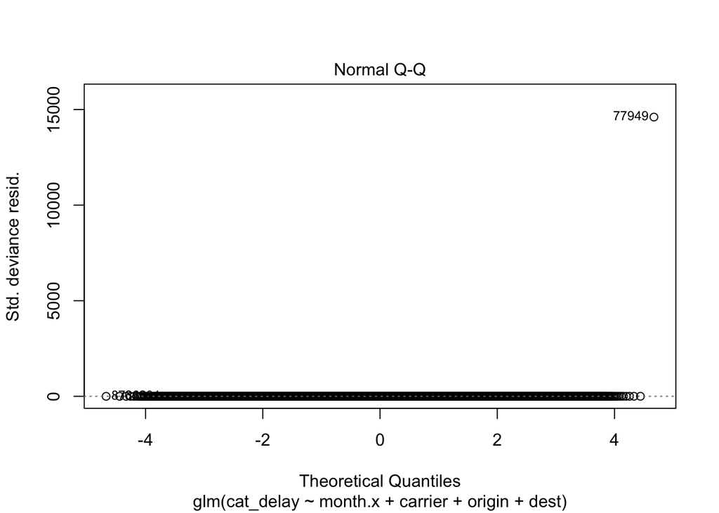

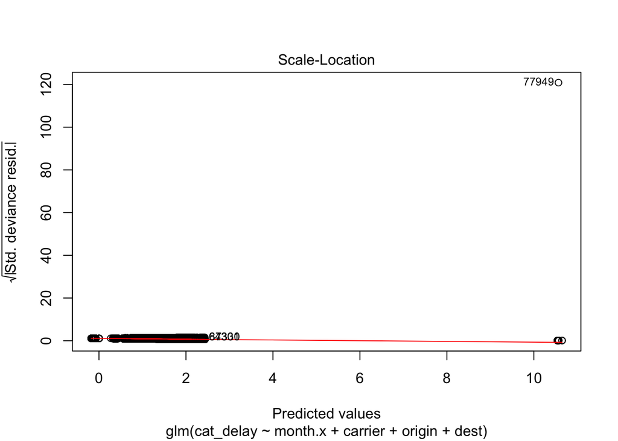

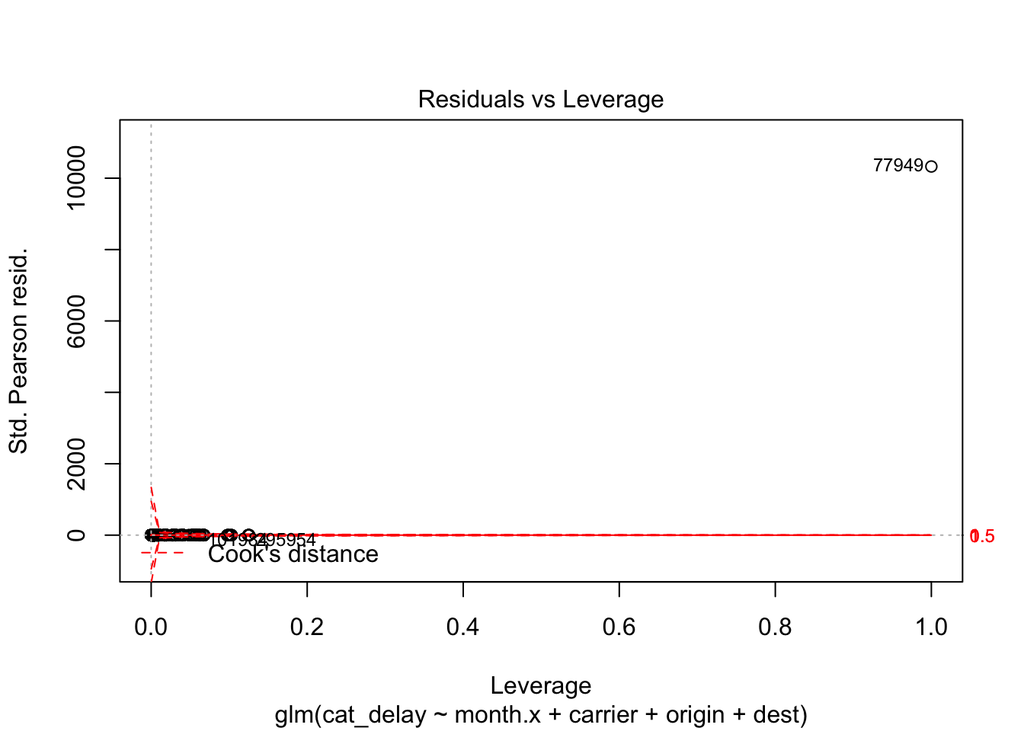

```r
plot(fit_update)
```